# Project Foundations for Data Science: FoodHub Data Analysis

### **Question 7**: Which are the top 5 restaurants in terms of the number of orders received?

```python
n=5
df['restaurant_name'].value_counts()[:n]
```

```
Shake Shack                  219
The Meatball Shop            132
Blue Ribbon Sushi            119
Blue Ribbon Fried Chicken     96
Parm                          68
Name: restaurant_name, dtype: int64
```

#### Observations: Shake Shack, The Meatball Shop, Blue Ribbon Sushi, Blue Ribbon Fried Chicken, and Parm are the top 5 restaurants in terms of orders received.

### **Question 8**: Which is the most popular cuisine on weekends?

```python
list_weekends=list(df[df['day_of_the_week']=='Weekend']['cuisine_type']) # Creates list of all weekend cuisines ordere#
weekend_cuisine_count = {i:list_weekends.count(i) for i in list_weekends} # Counts duplicates of weekend cuisine types #
print(weekend_cuisine_count) #prints cuisines with number of times that they duplicate #
```

```
{'Korean': 11, 'Japanese': 335, 'American': 415, 'Italian': 207, 'Mexican': 53, 'Mediterranean': 32, 'Chinese': 163, 'Indian': 49, 'Thai': 15, 'Southern': 11, 'French': 13, 'Spanish': 11, 'Middle Eastern': 32, 'Vietnamese': 4}
```

#### Observations: 'American' is the most popular cuisine on the weekends'

### **Question 9**: What percentage of the orders cost more than 20 dollars?

```python
# Using dataframe df: create list of orders that cost more than 20 dollars

over_twenty = df[df['cost_of_the_order'] > 20]   #creates new dataframe called over_twenty that only holds orders over 20 dollars#
print(over_twenty.shape) #providing shape tells us how many rows or orders  are over $20 #
print(555/1898) #dividing number of orders over $20 by the total number of orders in original dataframe 1898, we get the percentage of orders over $20#
```

```
(555, 9)
0.2924130663856691
```

#### Observations: Approximately 29% of orders were over $20

### **Question 10**: What is the mean order delivery time?

```python
df["delivery_time"].mean() #provide the mean of all the delivery times provided#
```

```
24.161749209694417
```

#### Observations: The approximate mean delivery time is 24 minutes

### **Question 11:** The company has decided to give 20% discount vouchers to the top 3 most frequent customers. Find the IDs of these customers and the number of orders they placed

```python
n=3 #variable assigned to be limiter. set to 3 for top 3 returned values
df['customer_id'].value_counts()[:n] #counts number of times a customer id repeats and then limits the list by 'n' value#
```

```
52832    13
47440    10
83287     9
Name: customer_id, dtype: int64
```

#### Observations: Customer ID 52832 placed 13 orders. Customer Id 47440 placed 10 orders, and customer ID 83287 placed 9 orders. These are the top 3 most frequent customers

### **Question 12**: Perform a multivariate analysis to explore relationships between the important variables in the dataset. (It is a good idea to explore relations between numerical variables as well as relations between numerical and categorical variables)

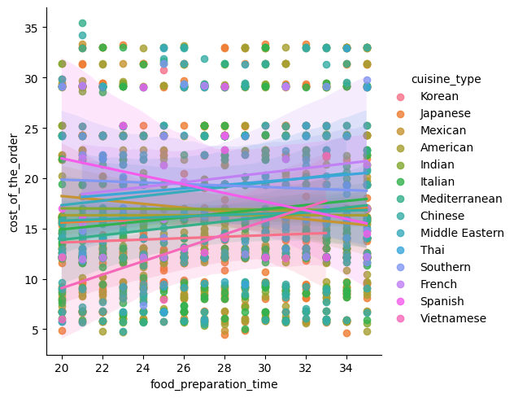

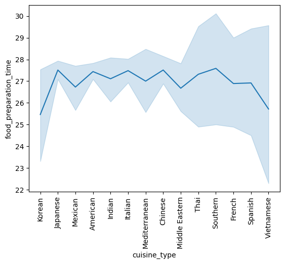

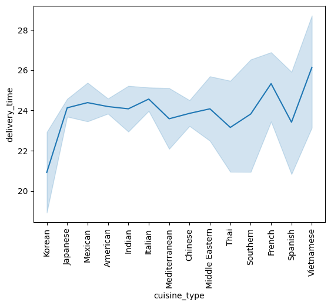

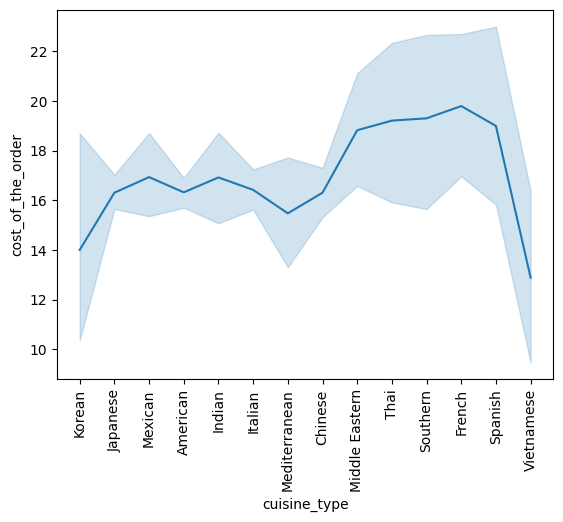

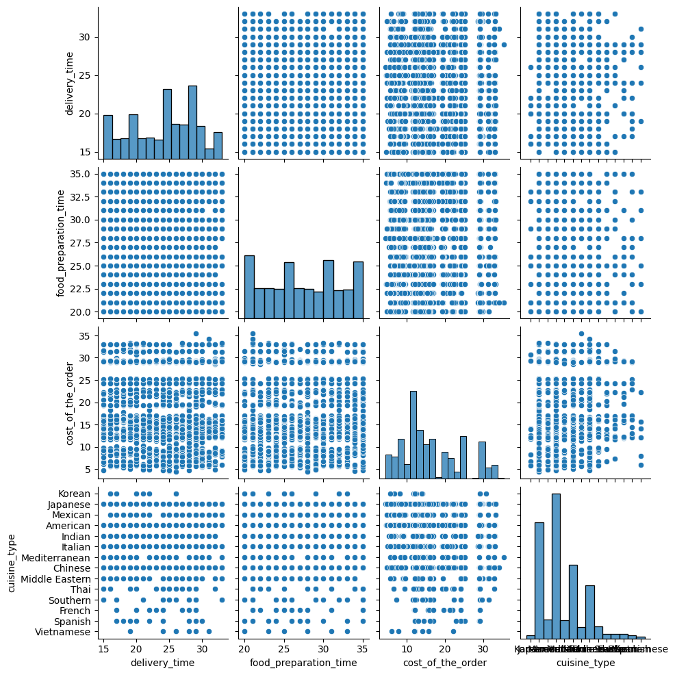

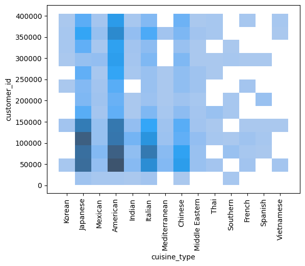

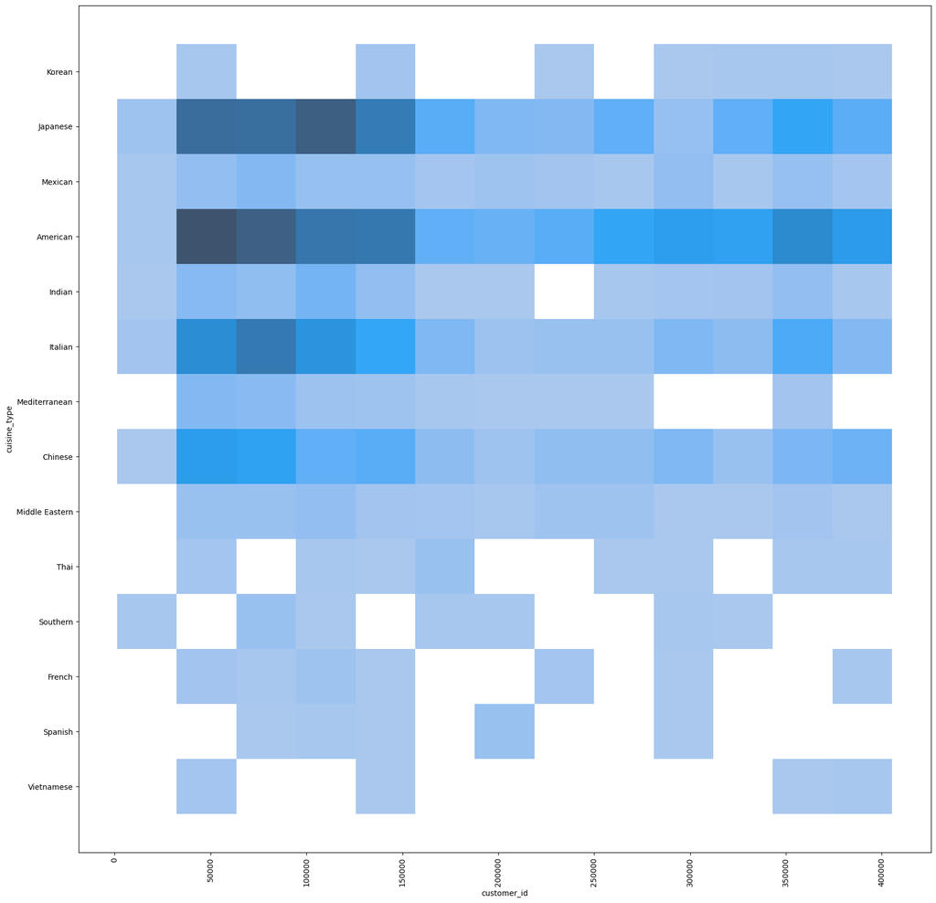

```python
### lmplot of delivey cost vs delivery time ###

sns.lmplot(data=df, x='food_preparation_time', y='cost_of_the_order', hue='cuisine_type')
plt.show()

# Lineplot of preparation time across cuisine type#
sns.lineplot(data=df, y='food_preparation_time', x='cuisine_type')
plt.xticks(rotation=90)
plt.show()

#Lineplot of delivery time across cuisine type#
sns.lineplot(data=df, y='delivery_time', x='cuisine_type')
plt.xticks(rotation=90)
plt.show()

sns.lineplot(data=df, y='cost_of_the_order', x='cuisine_type')
plt.xticks(rotation=90)
plt.show()

sns.pairplot(data=df, vars=["delivery_time","food_preparation_time", "cost_of_the_order", "cuisine_type"])
plt.show()

sns.histplot(data=df, x="cuisine_type", y='customer_id')
plt.xticks(rotation=90)
plt.show()

plt.figure(figsize=(20,20))
sns.histplot(data=df, y='cuisine_type', x='customer_id')
plt.xticks(rotation=90)
plt.show()
```

### **Question 13:** The company wants to provide a promotional offer in the advertisement of the restaurants. The condition to get the offer is that the restaurants must have a rating count of more than 50 and the average rating should be greater than 4. Find the restaurants fulfilling the criteria to get the promotional offer

```python
only_rated=df[df['rating'].isin(['1', '2', '3', '4', '5'])] #creates new df limited to only those orders with ratings#
only_rated['rating'] = only_rated['rating'].astype('int') #changes rating row from object to integer


print(only_rated['restaurant_name'].value_counts()) #counts the number of times each restaurant shows up in the df of only rated orders
Shake_Shack=only_rated[only_rated['restaurant_name']=='Shake Shack'] #creates df of only shake shack's ratings
print(Shake_Shack.head())
Shake_Shack_avg=Shake_Shack['rating'].mean() #assigns the mean of ss ratings to a value
print("Shake Shop's average rating is:", Shake_Shack_avg) #provides string with avg rating for ss

The_Meatball_Shop=only_rated[only_rated['restaurant_name']=='The Meatball Shop'] #creates df with only meatball shop
print(The_Meatball_Shop.head())
Meatball_Shop_avg=The_Meatball_Shop['rating'].mean()  #assigns the mean of mbs ratings to a value
print("The Meatball Shop's average rating is:", Meatball_Shop_avg) #prints string with average rating for mbs

Blue_Ribbon_Sushi=only_rated[only_rated['restaurant_name']=='Blue Ribbon Sushi'] #creates df with only brs
print(Blue_Ribbon_Sushi.head())
Blue_Ribbon_Sushi_avg=Blue_Ribbon_Sushi['rating'].mean() #assigns mean of brs to value
print("Blue Ribbon Sushi's average rating is:", Blue_Ribbon_Sushi_avg)  #prints string with average rating for brs

Blue_Ribbon_Chicken=only_rated[only_rated['restaurant_name']=='Blue Ribbon Fried Chicken'] #creates df w only brc
print(Blue_Ribbon_Chicken.head())
Blue_Ribbon_Chicken_avg=Blue_Ribbon_Chicken['rating'].mean() #assigns mean of ratings for brc to value
print("Blue Ribbon Chicken's average rating is:", Blue_Ribbon_Chicken_avg) #prints string w avg rating for brc

print("The meatball Shop's average rating is:", Meatball_Shop_avg,"/n","Shake Shack's average rating is:", Shake_Shack_avg, "/n", "Blue Ribbon Sushi's average rating is:", Blue_Ribbon_Sushi_avg,
      "Blue Ribbon Fried Chicken's average rating is:", Blue_Ribbon_Chicken_avg)   # prints total string for all shops averages

print()
print()
```

```
Shake Shack                    133
The Meatball Shop               84
Blue Ribbon Sushi               73
Blue Ribbon Fried Chicken       64
RedFarm Broadway                41
                              ...
Philippe Chow                    1
Dirty Bird To Go (archived)      1
The MasalaWala                   1
Kambi Ramen House                1
'wichcraft                       1
Name: restaurant_name, Length: 156, dtype: int64
    order_id  customer_id restaurant_name cuisine_type  cost_of_the_order  \
15   1477414        66222     Shake Shack     American              16.20
22   1478287       150599     Shake Shack     American              29.10
71   1476651        58092     Shake Shack     American               8.00
80   1477975        56722     Shake Shack     American               9.75
82   1477790       133617     Shake Shack     American               4.75

   day_of_the_week  rating  food_preparation_time  delivery_time
15         Weekend       5                     33             25
22         Weekday       5                     21             30
71         Weekend       5                     27             23
80         Weekend       5                     33             25
82         Weekday       4                     35             28
Shake Shop's average rating is: 4.2781954887218046
     order_id  customer_id    restaurant_name cuisine_type  cost_of_the_order  \
26    1476995       371590  The Meatball Shop      Italian              21.88
37    1476871       118709  The Meatball Shop      Italian              24.30
45    1476581       322162  The Meatball Shop      Italian               6.74
127   1477405       128243  The Meatball Shop      Italian               6.74
144   1478269       250494  The Meatball Shop      Italian              11.16

    day_of_the_week  rating  food_preparation_time  delivery_time
26          Weekday       5                     24             27
37          Weekday       4                     31             29
45          Weekend       5                     29             23
127         Weekend       5                     26             30
144         Weekday       5                     22             28
The Meatball Shop's average rating is: 4.511904761904762
```

[output cut: 21 more lines]

```
     cost_of_the_order day_of_the_week  rating  food_preparation_time  \
3                29.20         Weekend       3                     25
12               24.30         Weekend       5                     23
69               32.93         Weekend       5                     24
96               12.18         Weekday       3                     29
117               7.86         Weekday       4                     22

     delivery_time
3               15
12              17
69              23
96              27
117             33
Blue Ribbon Chicken's average rating is: 4.328125
The meatball Shop's average rating is: 4.511904761904762 /n Shake Shack's average rating is: 4.2781954887218046 /n Blue Ribbon Sushi's average rating is: 4.219178082191781 Blue Ribbon Fried Chicken's average rating is: 4.328125
```

#### Observations: Only 4 restaurants had more than 50 ratings and all 4 of them had an average rating of over 4. Those restaurants are, "The Shake Shack", "The Meatball Shop", "Blue Ribbon Sushi", and "Blue Ribbon Fried Chicken".

### **Question 14:** The company charges the restaurant 25% on the orders having cost greater than 20 dollars and 15% on the orders having cost greater than 5 dollars. Find the net revenue generated by the company across all orders

```python
over_twenty = df[df['cost_of_the_order'] > 20] #creates data frame of orders over 20 dollars
over_five = df[df['cost_of_the_order'] > 5] #creates data frame of orders over 5 dollars
print(over_twenty)
print(over_twenty_five)

net_revenue=((over_twenty['cost_of_the_order'].sum())*.25)+((over_five['cost_of_the_order'].sum())*.15) #calculates net revenue
print("The total revenue generated across all orders is:", net_revenue)
```

```
      order_id  customer_id                        restaurant_name  \
0      1477147       337525                                Hangawi
3      1477334       106968              Blue Ribbon Fried Chicken
5      1477224       147468                       Tamarind TriBeCa
12     1476966       129969              Blue Ribbon Fried Chicken
17     1477373       139885              Blue Ribbon Sushi Izakaya
...        ...          ...                                    ...
1884   1477437       304993                            Shake Shack
1885   1477550        97324                            Shake Shack
1892   1477473        97838                            Han Dynasty
1893   1476701       292602  Chipotle Mexican Grill $1.99 Delivery
1895   1477819        35309                      Blue Ribbon Sushi

     cuisine_type  cost_of_the_order day_of_the_week     rating  \
0          Korean              30.75         Weekend  Not given
```

[output cut: 68 more lines]

#### Observations: The total revenue genearated across all orders is approximately $8379.54

### **Question 15:** The company wants to analyze the total time required to deliver the food. What percentage of orders take more than 60 minutes to get delivered from the time the order is placed? (The food has to be prepared and then delivered)

```python
Total_processing_time=(df['food_preparation_time']+df['delivery_time']) #creates new df with food prep and delivery time added up
new_df = [df['food_preparation_time'], df['delivery_time'], Total_processing_time] #creates df with the 3 times together
display(new_df)
```

```
[0       25
 1       25
 2       23
 3       25
 4       25
         ..
 1893    31
 1894    31
 1895    31
 1896    23
 1897    28
 Name: food_preparation_time, Length: 1898, dtype: int64,
 0       20
 1       23
 2       28
```

[output cut: 21 more lines]

### **Question 16:** The company wants to analyze the delivery time of the orders on weekdays and weekends. How does the mean delivery time vary during weekdays and weekends?

```python
list_weekends_delivery=list(df[df['day_of_the_week']=='Weekend']['delivery_time']) #creates list of orders made on weekends
list_weekdays_delivery=list(df[df['day_of_the_week']=='Weekday']['delivery_time']) #creates list of orders made on weekdays
weekend_delivery_mean = np.average(list_weekends_delivery) #assigns average of weekend delivery times to a value
weekday_delivery_mean = np.average(list_weekdays_delivery) #assigns average of weekday delivery times to a value
print("The mean for weekend deliveries is:", weekend_delivery_mean)
print("The mean for weekday deliveries is:", weekday_delivery_mean)
print("Delivery difference is", (weekend_delivery_mean-weekday_delivery_mean))
print("Weekday deliveries, on average, are taking approximately", ((weekday_delivery_mean)-(weekend_delivery_mean)).round(),"more minutes than weekend deliveries.")
```

```
The mean for weekend deliveries is: 22.4700222057735
The mean for weekday deliveries is: 28.340036563071298
Delivery difference is -5.870014357297798
Weekday deliveries, on average, are taking approximately 6.0 more minutes than weekend deliveries.
```

### Conclusion and Recommendations

### **Question 17:** What are your conclusions from the analysis? What recommendations would you like to share to help improve the business? (You can use cuisine type and feedback ratings to drive your business recommendations)

There is a lot of inconsistency in the food prep time for, Southern, French, Spanish, and, Vietnamese cuisines. These orders also tend to have a large upward and downward swing in cost also. It is possible that these orders are of larger quantities resulting in longer food prep times. Either way, it may be good customer service to give an advisement of possible longer total time from order to delivery. Also, while they do some of our most expensive and hence, most profitable orders, they also do some of our least profitable, as well. Could be beneficial to add a minimum order size for delivery from these locations. It doesn't look like we do a majority of our orders in these cuisine types, so it shouldn't be too affecting to overall numbers. Also, there does not appear to be a large count of customer id's ordering from these locations, so there is the possibility that the majority of those ordering are very specific niche clients and would be willing to pay a premium for what they like.

### Recommendations: Advise customers of potential longer delivery times for restaurants providing Southern, French, Spanish, and Vietnamese cuisines. Add a minimum order size for delivery from restaurants providding Southern, French, Spanish, and Vietnamese cuisines.